# Regression Analysis

## Modeling with Categorical Inputs

For this exercise you will fit a linear model to the `flowers` data, to predict `Flowers` as a function of `Time` and `Intensity`.

The model formula `fmla` that you created in the previous exercise is still in your workspace, as is the model matrix `mmat.`

```r
# Fit a model to predict Flowers from Intensity and Time : flower_model
flower_model <- lm(formula = fmla,
                   data = flowers)

# Use summary on mmat to remind yourself of its structure
summary(mmat)
```

```
  (Intercept)   Intensity        Time
 Min.   :1    Min.   :150   Min.   :1.0
 1st Qu.:1    1st Qu.:300   1st Qu.:1.0
 Median :1    Median :525   Median :1.5
 Mean   :1    Mean   :525   Mean   :1.5
 3rd Qu.:1    3rd Qu.:750   3rd Qu.:2.0
 Max.   :1    Max.   :900   Max.   :2.0
```

```r
# Use summary to examine flower_model
summary(flower_model)
```

```
Call:
lm(formula = fmla, data = flowers)

Residuals:
   Min     1Q Median     3Q    Max
-9.652 -4.139 -1.558  5.632 12.165

Coefficients:
             Estimate Std. Error t value Pr(>|t|)
(Intercept) 59.147500   4.954465  11.938 8.01e-11 ***
Intensity   -0.040471   0.005132  -7.886 1.04e-07 ***
Time        12.158333   2.629557   4.624 0.000146 ***
---
Signif. codes:  0 '***' 0.001 '**' 0.01 '*' 0.05 '.' 0.1 ' ' 1

Residual standard error: 6.441 on 21 degrees of freedom
Multiple R-squared:  0.7992,    Adjusted R-squared:   0.78
F-statistic: 41.78 on 2 and 21 DF,  p-value: 4.786e-08
```

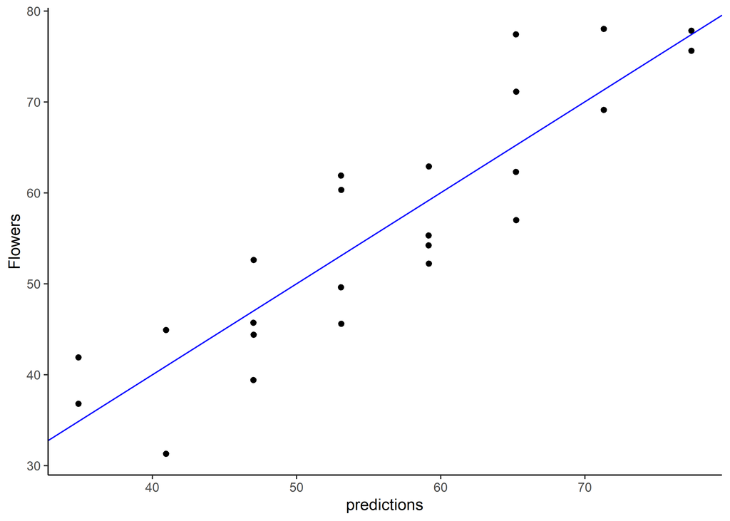

```r
# Predict the number of flowers on each plant
flowers$predictions <- predict(object = flower_model,
                               newdata = flowers)

# Plot predictions vs actual flowers (predictions on x-axis)
ggplot(flowers,
       aes(x = predictions,
           y = Flowers)) +
  geom_point() +
  geom_abline(color = "blue") +
  theme_classic()
```

## Modeling an Interaction

In this exercise you will use interactions to model the effect of gender and gastric activity on alcohol metabolism.

The data frame `alcohol` has columns:

- `Metabol`: the alcohol metabolism rate
- `Gastric`: the rate of gastric alcohol dehydrogenase activity
- `Sex`: the sex of the drinker (`Male` or `Female`)

In the video, we fit three models to the `alcohol` data:

- One with only additive (main effect) terms : `Metabol ~ Gastric + Sex`
- Two models, each with interactions between gastric activity and sex

We saw that one of the models with interaction terms had a better R-squared than the additive model, suggesting that using interaction terms gives a better fit. In this exercise we will compare the R-squared of one of the interaction models to the main-effects-only model.

Recall that the operator `:` designates the interaction between two variables. The operator `*` designates the interaction between the two variables, plus the main effects.

`x*y = x + y + x:y`

```r
alcohol <- read_csv(file = "Alcohol.csv")

# alcohol is in the workspace
summary(alcohol)
```

```
    Subject         Metabol          Gastric          Sex
 Min.   : 1.00   Min.   : 0.100   Min.   :0.800   Length:32
 1st Qu.: 8.75   1st Qu.: 0.600   1st Qu.:1.200   Class :character
 Median :16.50   Median : 1.700   Median :1.600   Mode  :character
 Mean   :16.50   Mean   : 2.422   Mean   :1.863
 3rd Qu.:24.25   3rd Qu.: 2.925   3rd Qu.:2.200
 Max.   :32.00   Max.   :12.300   Max.   :5.200
   Alcohol
 Length:32
 Class :character
 Mode  :character
```

```r
# Create the formula with main effects only
(fmla_add <- as.formula(Metabol ~ Gastric + Sex))
```

```
Metabol ~ Gastric + Sex
```

```r
# Create the formula with interactions and only main effect of Gastric
(fmla_interaction <- as.formula(Metabol ~ Gastric + Gastric:Sex))
```

```
Metabol ~ Gastric + Gastric:Sex
```

```r
# Fit the main effects only model
model_add <- lm(formula = fmla_add,
                data = alcohol)

# Fit the interaction model
model_interaction <- lm(formula = fmla_interaction,
                data = alcohol)

# Call summary on both models and compare
summary(model_add)
```

```
Call:
lm(formula = fmla_add, data = alcohol)

Residuals:
    Min      1Q  Median      3Q     Max
-2.2779 -0.6328 -0.0966  0.5783  4.5703

Coefficients:
            Estimate Std. Error t value Pr(>|t|)
(Intercept)  -1.9466     0.5198  -3.745 0.000796 ***
Gastric       1.9656     0.2674   7.352 4.24e-08 ***
SexMale       1.6174     0.5114   3.163 0.003649 **
---
Signif. codes:  0 '***' 0.001 '**' 0.01 '*' 0.05 '.' 0.1 ' ' 1

Residual standard error: 1.331 on 29 degrees of freedom
Multiple R-squared:  0.7654,    Adjusted R-squared:  0.7492
F-statistic: 47.31 on 2 and 29 DF,  p-value: 7.41e-10
```

```r
summary(model_interaction)
```

```
Call:
lm(formula = fmla_interaction, data = alcohol)

Residuals:
    Min      1Q  Median      3Q     Max
-2.4656 -0.5091  0.0143  0.5660  4.0668

Coefficients:
                Estimate Std. Error t value Pr(>|t|)
(Intercept)      -0.7504     0.5310  -1.413 0.168236
Gastric           1.1489     0.3450   3.331 0.002372 **
Gastric:SexMale   1.0422     0.2412   4.321 0.000166 ***
---
Signif. codes:  0 '***' 0.001 '**' 0.01 '*' 0.05 '.' 0.1 ' ' 1

Residual standard error: 1.204 on 29 degrees of freedom
Multiple R-squared:  0.8081,    Adjusted R-squared:  0.7948
F-statistic: 61.05 on 2 and 29 DF,  p-value: 4.033e-11
```

An interaction appears to give a better fit to the data.

In this exercise, you will compare the performance of the interaction model you fit in the previous exercise to the performance of a main-effects only model. Because this data set is small, we will use cross-validation to simulate making predictions on out-of-sample data.

You will begin to use the `dplyr` package to do calculations.

- `mutate()` adds new columns to a tbl (a type of data frame)
- `group_by()` specifies how rows are grouped in a tbl
- `summarize()` computes summary statistics of a column

You will also use `tidyr`’s `gather()` which takes multiple columns and collapses them into key-value pairs.

```r
# Create the splitting plan for 3-fold cross validation
set.seed(34245)  # set the seed for reproducibility
splitPlan <- kWayCrossValidation(nrow(alcohol),
                                 3,
                                 NULL,
                                 NULL)

# Sample code: Get cross-val predictions for main-effects only model
alcohol$pred_add <- 0  # initialize the prediction vector
for(i in 1:3) {
  split <- splitPlan[[i]]
  model_add <- lm(fmla_add,
                  data = alcohol[split$train,])
  alcohol$pred_add[split$app] <- predict(model_add,
                                         newdata = alcohol[split$app,])
}

# Get the cross-val predictions for the model with interactions
alcohol$pred_interaction <- 0 # initialize the prediction vector
for(i in 1:3) {
  split <- splitPlan[[i]]
  model_interaction <- lm(fmla_interaction,
                          data = alcohol[split$train,])
  alcohol$pred_interaction[split$app] <- predict(model_interaction,
                                                 newdata = alcohol[split$app,])
}

# Get RMSE
alcohol %>%
  gather(key = modeltype, value = pred, pred_add, pred_interaction) %>%
  mutate(residuals = Metabol - pred) %>%
  group_by(modeltype) %>%
  summarize(rmse = sqrt(mean(residuals^2)))
```

| modeltype | rmse |
| --- | --- |
| pred_add | 1.375565 |
| pred_interaction | 1.303637 |

Cross-validation confirms that a model with interaction will likely give better predictions.

```r
fdata <- read_csv(file = "Toy.csv")

# fdata is in the workspace
summary(fdata)
```

```
       y                 pred             label
 Min.   :  -5.894   Min.   :   1.072   Length:100
 1st Qu.:   5.407   1st Qu.:   6.373   Class :character
 Median :  57.374   Median :  55.693   Mode  :character
 Mean   : 306.204   Mean   : 305.905
 3rd Qu.: 550.903   3rd Qu.: 547.886
 Max.   :1101.619   Max.   :1098.896
```

```r
# Examine the data: generate the summaries for the groups large and small:
fdata %>%
    group_by(label) %>%         # group by small/large purchases
    summarize(min  = min(y),    # min of y
              mean = mean(y),   # mean of y
              max  = max(y))    # max of y
```

| label | min | mean | max |
| --- | --- | --- | --- |
| large purchases | 96.119814 | 605.928673 | 1101.61864 |
| small purchases | -5.893499 | 6.478254 | 18.62829 |

```r
# Fill in the blanks to add error columns
fdata2 <- fdata %>%
         group_by(label) %>%                # group by label
           mutate(residual = y - pred,      # Residual
                  relerr   = (y - pred)/y)  # Relative error

# Compare the rmse and rmse.rel of the large and small groups:
fdata2 %>%
  group_by(label) %>%
  summarize(rmse     = sqrt(mean((y - pred)^2)),       # RMSE
            rmse.rel = sqrt(mean(((y - pred)/y)^2)))   # Root mean squared relative error
```

| label | rmse | rmse.rel |
| --- | --- | --- |
| large purchases | 5.544439 | 0.01473322 |
| small purchases | 4.014969 | 1.24965673 |

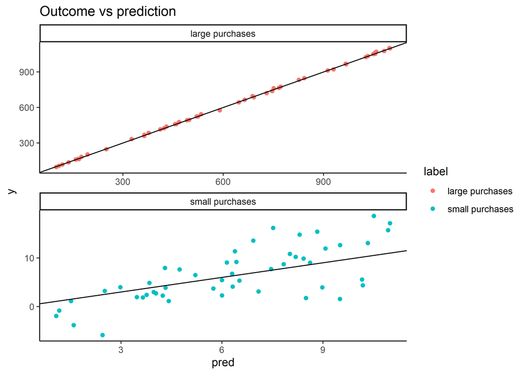

```r
# Plot the predictions for both groups of purchases
ggplot(fdata2, aes(x = pred, y = y, color = label)) +
  geom_point() +
  geom_abline() +
  facet_wrap(~ label, ncol = 1, scales = "free") +
  ggtitle("Outcome vs prediction") +
  theme_classic()
```

Notice from this example how a model with larger RMSE might still be better, if relative errors are more important than absolute errors.

## Modeling Log-transformed Monetary Output

In this exercise, you will practice modeling on log-transformed monetary output, and then transforming the “log-money” predictions back into monetary units. The data loaded into your workspace records subjects’ incomes in 2005 (`Income2005`), as well as the results of several aptitude tests taken by the subjects in 1981:

- `Arith`
- `Word`
- `Parag`
- `Math`
- `AFQT` (Percentile on the Armed Forces Qualifying Test) The data have already been split into training and test sets (`income_train` and `income_test` respectively) and are in the workspace. You will build a model of log(income) from the inputs, and then convert log(income) back into income.

```r
income_train <- read_csv(file = "Income2005 Train.csv")
income_test <- read_csv(file = "Income2005 Test.csv")

# Examine Income2005 in the training set
summary(income_train$Income2005)
```

```
   Min. 1st Qu.  Median    Mean 3rd Qu.    Max.
     63   23000   39000   49894   61500  703637
```

```r
# Write the formula for log income as a function of the tests and print it
(fmla.log <- as.formula(log(Income2005) ~ Arith + Word + Parag + Math + AFQT))
```

```
log(Income2005) ~ Arith + Word + Parag + Math + AFQT
```

```r
# Fit the linear model
model.log <-  lm(formula = fmla.log,
                 data = income_train)

# Make predictions on income_test
income_test$logpred <- predict(object = model.log,
                               newdata = income_test)
summary(income_test$logpred)
```

```
   Min. 1st Qu.  Median    Mean 3rd Qu.    Max.
  9.766  10.133  10.423  10.419  10.705  11.006
```

```r
# Convert the predictions to monetary units
income_test$pred.income <- exp(income_test$logpred)
summary(income_test$pred.income)
```

```
   Min. 1st Qu.  Median    Mean 3rd Qu.    Max.
  17432   25167   33615   35363   44566   60217
```

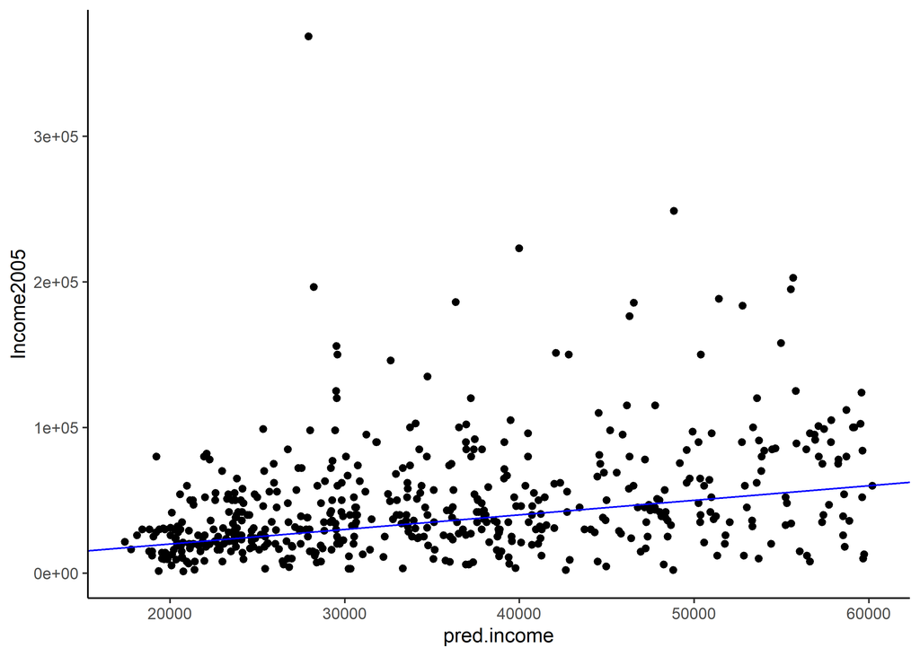

```r
#  Plot predicted income (x axis) vs income
ggplot(income_test,
       aes(x = pred.income,
           y = Income2005)) +
  geom_point() +
  geom_abline(color = "blue") +
  theme_classic()
```

Remember that when you transform the output before modeling, you have to ‘reverse transform’ the resulting predictions after applying the model.

## Comparing RMSE and Root-Mean-Squared Relative Error

In this exercise, you will show that log-transforming a monetary output before modeling improves mean relative error (but increases RMSE) compared to modeling the monetary output directly. You will compare the results of `model.log` from the previous exercise to a model (`model.abs`) that directly fits income.

The `income_train` and `income_test` datasets are loaded in your workspace, along with your model, `model.log`.

Also in the workspace:

`model.abs`: a model that directly fits income to the inputs using the formula

`Income2005 ~ Arith + Word + Parag + Math + AFQT`

```r
# Create fmla.abs
(fmla.abs <- as.formula(Income2005 ~ Arith + Word + Parag + Math + AFQT))
```

```
Income2005 ~ Arith + Word + Parag + Math + AFQT
```

```r
# Building absolute model
model.abs <- lm(formula = fmla.abs,
                data = income_train)

# model.abs is in the workspace
summary(model.abs)
```

```
Call:
lm(formula = fmla.abs, data = income_train)

Residuals:
   Min     1Q Median     3Q    Max
-78728 -24137  -6979  11964 648573

Coefficients:
            Estimate Std. Error t value Pr(>|t|)
(Intercept)  17516.7     6420.1   2.728  0.00642 **
Arith         1552.3      303.4   5.116 3.41e-07 ***
Word          -132.3      265.0  -0.499  0.61754
Parag        -1155.1      618.3  -1.868  0.06189 .
Math           725.5      372.0   1.950  0.05127 .
AFQT           177.8      144.1   1.234  0.21734
---
Signif. codes:  0 '***' 0.001 '**' 0.01 '*' 0.05 '.' 0.1 ' ' 1

Residual standard error: 45500 on 2063 degrees of freedom
Multiple R-squared:  0.1165,    Adjusted R-squared:  0.1144
F-statistic:  54.4 on 5 and 2063 DF,  p-value: < 2.2e-16
```

```r
# Add predictions to the test set
income_test <- income_test %>%
  mutate(pred.absmodel = predict(object = model.abs,
                                 newdata = income_test),        # predictions from model.abs
         pred.logmodel = exp(predict(model.log, income_test)))   # predictions from model.log

# Gather the predictions and calculate residuals and relative error
income_long <- income_test %>%
  gather(key = modeltype, value = pred, pred.absmodel, pred.logmodel) %>%
  mutate(residual = pred - Income2005,   # residuals
         relerr   = (pred - Income2005)/Income2005)   # relative error

# Calculate RMSE and relative RMSE and compare
income_long %>%
  group_by(modeltype) %>%      # group by modeltype
  summarize(rmse     = sqrt(mean(residual^2)),    # RMSE
            rmse.rel = sqrt(mean(relerr^2)))    # Root mean squared relative error
```

| modeltype | rmse | rmse.rel |
| --- | --- | --- |
| pred.absmodel | 37448.37 | 3.183705 |
| pred.logmodel | 39234.90 | 2.218663 |

You’ve seen how modeling log(income) can reduce the relative error of the fit, at the cost of increased RMSE. Which tradeoff to make depends on the goals of your project.

## Input Transforms: the “hockey stick”

In this exercise, we will build a model to predict price from a measure of the house’s size (surface area). The data set `houseprice` has the columns:

- `price` : house price in units of $1000
- `size` : surface area A scatterplot of the data shows that the data is quite non-linear: a sort of “hockey-stick” where price is fairly flat for smaller houses, but rises steeply as the house gets larger. Quadratics and tritics are often good functional forms to express hockey-stick like relationships. Note that there may not be a “physical” reason that `price` is related to the square of the `size`; a quadratic is simply a closed form approximation of the observed relationship.

[figure not shown]

You will fit a model to predict price as a function of the squared size, and look at its fit on the training data.

Because `^` is also a symbol to express interactions, use the function `I()` to treat the expression `x^2` “as is”: that is, as the square of x rather than the interaction of `x` with itself.

`exampleFormula = y ~ I(x^2)`

```r
# houseprice is in the workspace
summary(houseprice)
```

```
      size           price
 Min.   : 44.0   Min.   : 42.0
 1st Qu.: 73.5   1st Qu.:164.5
 Median : 91.0   Median :203.5
 Mean   : 94.3   Mean   :249.2
 3rd Qu.:118.5   3rd Qu.:287.8
 Max.   :150.0   Max.   :573.0
```

```r
# Create the formula for price as a function of squared size
(fmla_sqr <- as.formula(price ~ I(size^2)))
```

```
price ~ I(size^2)
```

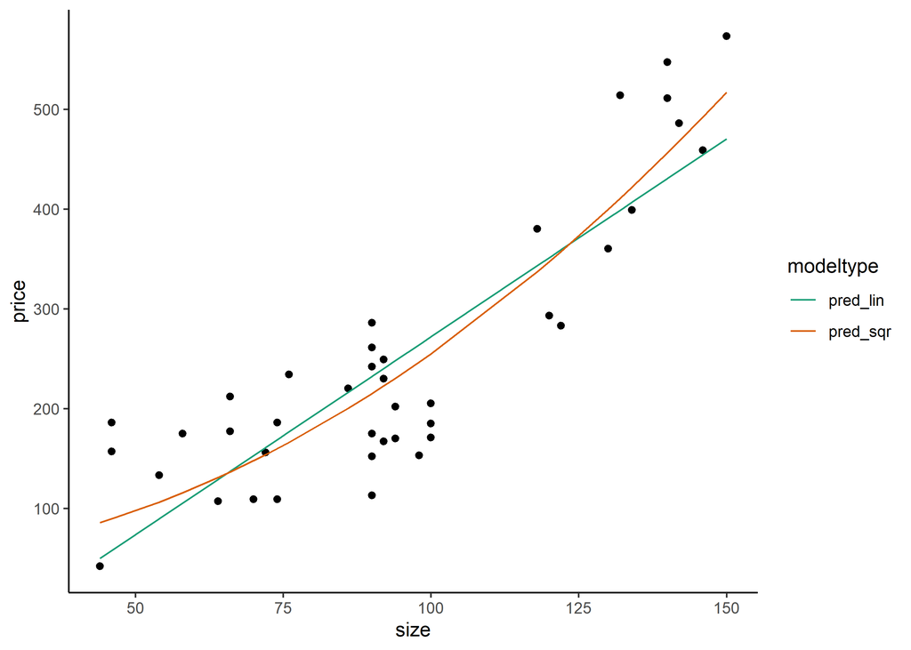

```r
# Fit a model of price as a function of squared size (use fmla_sqr)
model_sqr <- lm(formula = fmla_sqr,
                data = houseprice)

# Fit a model of price as a linear function of size
model_lin <- lm(formula = price ~ size,
                data = houseprice)

# Make predictions and compare
houseprice %>%
    mutate(pred_lin = predict(object = model_lin,
                              newdata = houseprice),       # predictions from linear model
           pred_sqr = predict(object = model_sqr,
                              newdata = houseprice)) %>%   # predictions from quadratic model
    gather(key = modeltype, value = pred, pred_lin, pred_sqr) %>% # gather the predictions
    ggplot(aes(x = size)) +
       geom_point(aes(y = price)) +                   # actual prices
       geom_line(aes(y = pred, color = modeltype)) + # the predictions
       scale_color_brewer(palette = "Dark2") +
    theme_classic()
```

Great work! In the next chapter you will see how transformations like this can sometimes be learned automatically.

## Input Transforms: the “hockey stick” (2)

In the last exercise you saw that a quadratic model seems to fit the `houseprice` data better than a linear model. In this exercise you will confirm whether the quadratic model would perform better on out-of-sample data. Since this data set is small, you will use cross-validation. The quadratic formula `fmla_sqr` that you created in the last exercise is in your workspace.

For comparison, the sample code will calculate cross-validation predictions from a linear model `price ~ size`.

```r
# houseprice is in the workspace
summary(houseprice)
```

```
      size           price
 Min.   : 44.0   Min.   : 42.0
 1st Qu.: 73.5   1st Qu.:164.5
 Median : 91.0   Median :203.5
 Mean   : 94.3   Mean   :249.2
 3rd Qu.:118.5   3rd Qu.:287.8
 Max.   :150.0   Max.   :573.0
```

```r
# fmla_sqr is in the workspace
fmla_sqr
```

```
price ~ I(size^2)
```

```r
# Create a splitting plan for 3-fold cross validation
set.seed(34245)  # set the seed for reproducibility
splitPlan <- kWayCrossValidation(nrow(houseprice),
                                 3,
                                 NULL,
                                 NULL)

# Sample code: get cross-val predictions for price ~ size
houseprice$pred_lin <- 0  # initialize the prediction vector
for(i in 1:3) {
  split <- splitPlan[[i]]
  model_lin <- lm(price ~ size, data = houseprice[split$train,])
  houseprice$pred_lin[split$app] <- predict(model_lin, newdata = houseprice[split$app,])
}

# Get cross-val predictions for price as a function of size^2 (use fmla_sqr)
houseprice$pred_sqr <- 0 # initialize the prediction vector
for(i in 1:3) {
  split <- splitPlan[[i]]
  model_sqr <- lm(formula = fmla_sqr, data = houseprice[split$train, ])
  houseprice$pred_sqr[split$app] <- predict(model_sqr, newdata = houseprice[split$app, ])
}

# Gather the predictions and calculate the residuals
houseprice_long <- houseprice %>%
  gather(key = modeltype, value = pred, pred_lin, pred_sqr) %>%
  mutate(residuals = pred - price)

# Compare the cross-validated RMSE for the two models
houseprice_long %>%
  group_by(modeltype) %>% # group by modeltype
  summarize(rmse = sqrt(mean(residuals^2)))
```

| modeltype | rmse |
| --- | --- |
| pred_lin | 73.14852 |
| pred_sqr | 60.27335 |

You’ve confirmed that the quadratic input tranformation improved the model. In the next chapter you will see how transformations like this can sometimes be learned automatically.

## Fit a model of Sparrow Survival Probability

In this exercise, you will estimate the probability that a sparrow survives a severe winter storm, based on physical characteristics of the sparrow. The dataset `sparrow` is loaded into your workspace. The outcome to be predicted is `status` (“Survived”, “Perished”). The variables we will consider are:

- `total_length` : length of the bird from tip of beak to tip of tail (mm)
- `weight` : in grams
- `humerus` : length of humerus (“upper arm bone” that connects the wing to the body) (inches)

Remember that when using `glm()` to create a logistic regression model, you must explicitly specify that `family = binomial`:

`glm(formula, data = data, family = binomial)`

You will call `summary()`, `broom::glance()` to see different functions for examining a logistic regression model. One of the diagnostics that you will look at is the analog to $R^2$, called $pseudo-R^2$.

$pseudeR^2 = 1 - \frac{deviance}{null.deviance}$

You can think of deviance as analogous to variance: it is a measure of the variation in categorical data. The $pseudoR^2$ is analogous to $R^2$ for standard regression: $R^2$ is a measure of the “variance explained” of a regression model. The $pseudoR^2$ is a measure of the “deviance explained”.

```r
sparrow <- read_csv(file = "Sparrow.csv")
head(sparrow)
```

| status | age | total_length | wingspan | weight | beak_head | humerus | femur | legbone | skull | sternum |
| --- | --- | --- | --- | --- | --- | --- | --- | --- | --- | --- |
| Survived | adult | 154 | 241 | 24.5 | 31.2 | 0.69 | 0.67 | 1.02 | 0.59 | 0.83 |
| Survived | adult | 160 | 252 | 26.9 | 30.8 | 0.74 | 0.71 | 1.18 | 0.60 | 0.84 |
| Survived | adult | 155 | 243 | 26.9 | 30.6 | 0.73 | 0.70 | 1.15 | 0.60 | 0.85 |
| Survived | adult | 154 | 245 | 24.3 | 31.7 | 0.74 | 0.69 | 1.15 | 0.58 | 0.84 |
| Survived | adult | 156 | 247 | 24.1 | 31.5 | 0.71 | 0.71 | 1.13 | 0.57 | 0.82 |
| Survived | adult | 161 | 253 | 26.5 | 31.8 | 0.78 | 0.74 | 1.14 | 0.61 | 0.89 |

```r
# sparrow is in the workspace
summary(sparrow)
```

```
    status              age             total_length      wingspan
 Length:87          Length:87          Min.   :153.0   Min.   :236.0
 Class :character   Class :character   1st Qu.:158.0   1st Qu.:245.0
 Mode  :character   Mode  :character   Median :160.0   Median :247.0
                                       Mean   :160.4   Mean   :247.5
                                       3rd Qu.:162.5   3rd Qu.:251.0
                                       Max.   :167.0   Max.   :256.0
     weight       beak_head        humerus           femur
 Min.   :23.2   Min.   :29.80   Min.   :0.6600   Min.   :0.6500
 1st Qu.:24.7   1st Qu.:31.40   1st Qu.:0.7250   1st Qu.:0.7000
 Median :25.8   Median :31.70   Median :0.7400   Median :0.7100
 Mean   :25.8   Mean   :31.64   Mean   :0.7353   Mean   :0.7134
 3rd Qu.:26.7   3rd Qu.:32.10   3rd Qu.:0.7500   3rd Qu.:0.7300
 Max.   :31.0   Max.   :33.00   Max.   :0.7800   Max.   :0.7600
    legbone          skull           sternum
 Min.   :1.010   Min.   :0.5600   Min.   :0.7700
 1st Qu.:1.110   1st Qu.:0.5900   1st Qu.:0.8300
 Median :1.130   Median :0.6000   Median :0.8500
 Mean   :1.131   Mean   :0.6032   Mean   :0.8511
 3rd Qu.:1.160   3rd Qu.:0.6100   3rd Qu.:0.8800
 Max.   :1.230   Max.   :0.6400   Max.   :0.9300
```

```r
# Create the survived column
sparrow$survived <- ifelse(test = sparrow$status == "Survived",
                           yes = TRUE,
                           no = FALSE)

# Create the formula
(fmla <- as.formula(survived ~ total_length + weight + humerus))
```

```
survived ~ total_length + weight + humerus
```

```r
# Fit the logistic regression model
sparrow_model <- glm(formula = fmla,
                     data = sparrow,
                     family = "binomial")

# Call summary
summary(sparrow_model)
```

```
Call:
glm(formula = fmla, family = "binomial", data = sparrow)

Deviance Residuals:
    Min       1Q   Median       3Q      Max
-2.1117  -0.6026   0.2871   0.6577   1.7082

Coefficients:
             Estimate Std. Error z value Pr(>|z|)
(Intercept)   46.8813    16.9631   2.764 0.005715 **
total_length  -0.5435     0.1409  -3.858 0.000115 ***
weight        -0.5689     0.2771  -2.053 0.040060 *
humerus       75.4610    19.1586   3.939 8.19e-05 ***
---
Signif. codes:  0 '***' 0.001 '**' 0.01 '*' 0.05 '.' 0.1 ' ' 1

(Dispersion parameter for binomial family taken to be 1)

    Null deviance: 118.008  on 86  degrees of freedom
Residual deviance:  75.094  on 83  degrees of freedom
AIC: 83.094

Number of Fisher Scoring iterations: 5
```

```r
# Call glance
(perf <- glance(sparrow_model))
```

| null.deviance | df.null | logLik | AIC | BIC | deviance | df.residual | nobs |
| --- | --- | --- | --- | --- | --- | --- | --- |
| 118.0084 | 86 | -37.54718 | 83.09436 | 92.95799 | 75.09436 | 83 | 87 |

```r
# Calculate pseudo-R-squared
(pseudoR2 <- 1 - (perf$deviance)/(perf$null.deviance))
```

```
[1] 0.3636526
```

You’ve fit a logistic regression model to predict probabilities! When looking at the $pseudoR^2$ of a logistic regression model, you should hope to see a value close to 1.

## Predict Sparrow Survival

In this exercise you will predict the probability of survival using the sparrow survival model from the previous exercise.

Recall that when calling `predict()` to get the predicted probabilities from a `glm()` model, you must specify that you want the response:

`predict(model, type = "response")`

Otherwise, `predict()` on a logistic regression model returns the predicted log-odds of the event, not the probability.

You will also use the `GainCurvePlot()` function to plot the gain curve from the model predictions. If the model’s gain curve is close to the ideal (“wizard”) gain curve, then the model sorted the sparrows well: that is, the model predicted that sparrows that actually survived would have a higher probability of survival. The inputs to the `GainCurvePlot()` function are:

- `frame` : data frame with prediction column and ground truth column
- `xvar` : the name of the column of predictions (as a string)
- `truthVar` : the name of the column with actual outcome (as a string)
- `title` : a title for the plot (as a string)

`GainCurvePlot(frame, xvar, truthVar, title)`

```r
# sparrow is in the workspace
summary(sparrow)
```

```
    status              age             total_length      wingspan
 Length:87          Length:87          Min.   :153.0   Min.   :236.0
 Class :character   Class :character   1st Qu.:158.0   1st Qu.:245.0
 Mode  :character   Mode  :character   Median :160.0   Median :247.0
                                       Mean   :160.4   Mean   :247.5
                                       3rd Qu.:162.5   3rd Qu.:251.0
                                       Max.   :167.0   Max.   :256.0
     weight       beak_head        humerus           femur
 Min.   :23.2   Min.   :29.80   Min.   :0.6600   Min.   :0.6500
 1st Qu.:24.7   1st Qu.:31.40   1st Qu.:0.7250   1st Qu.:0.7000
 Median :25.8   Median :31.70   Median :0.7400   Median :0.7100
 Mean   :25.8   Mean   :31.64   Mean   :0.7353   Mean   :0.7134
 3rd Qu.:26.7   3rd Qu.:32.10   3rd Qu.:0.7500   3rd Qu.:0.7300
 Max.   :31.0   Max.   :33.00   Max.   :0.7800   Max.   :0.7600
    legbone          skull           sternum        survived
 Min.   :1.010   Min.   :0.5600   Min.   :0.7700   Mode :logical
 1st Qu.:1.110   1st Qu.:0.5900   1st Qu.:0.8300   FALSE:36
 Median :1.130   Median :0.6000   Median :0.8500   TRUE :51
 Mean   :1.131   Mean   :0.6032   Mean   :0.8511
 3rd Qu.:1.160   3rd Qu.:0.6100   3rd Qu.:0.8800
 Max.   :1.230   Max.   :0.6400   Max.   :0.9300
```

```r
# sparrow_model is in the workspace
summary(sparrow_model)
```

```
Call:
glm(formula = fmla, family = "binomial", data = sparrow)

Deviance Residuals:
    Min       1Q   Median       3Q      Max
-2.1117  -0.6026   0.2871   0.6577   1.7082

Coefficients:
             Estimate Std. Error z value Pr(>|z|)
(Intercept)   46.8813    16.9631   2.764 0.005715 **
total_length  -0.5435     0.1409  -3.858 0.000115 ***
weight        -0.5689     0.2771  -2.053 0.040060 *
humerus       75.4610    19.1586   3.939 8.19e-05 ***
---
Signif. codes:  0 '***' 0.001 '**' 0.01 '*' 0.05 '.' 0.1 ' ' 1

(Dispersion parameter for binomial family taken to be 1)

    Null deviance: 118.008  on 86  degrees of freedom
Residual deviance:  75.094  on 83  degrees of freedom
AIC: 83.094

Number of Fisher Scoring iterations: 5
```

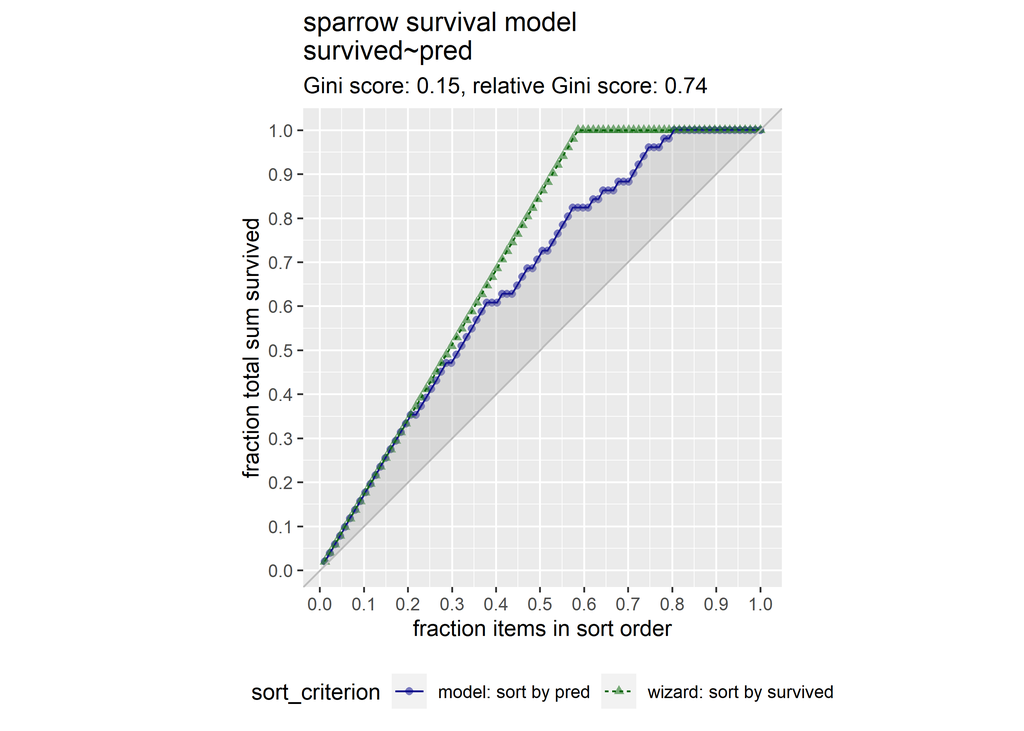

```r
# Make predictions
sparrow$pred <- predict(object = sparrow_model,
                        newdata = sparrow,
                        type = "response")

# Look at gain curve
GainCurvePlot(frame = sparrow,
              xvar = "pred",
              truthVar = "survived",
              "sparrow survival model")
```

You see from the gain curve that the model follows the wizard curve for about the first 30% of the data, identifying about 45% of the surviving sparrows with only a few false positives.

## Poisson or Quasipoisson

One of the assumptions of Poisson regression to predict counts is that the event you are counting is Poisson distributed: the average count per unit time is the same as the variance of the count. In practice, “the same” means that the mean and the variance should be of a similar order of magnitude.

When the variance is much larger than the mean, the Poisson assumption doesn’t apply, and one solution is to use quasipoisson regression, which does not assume that variance=mean.

For each of the following situations, decide if Poisson regression would be suitable, or if you should use quasipoisson regression.

For which situations can you use Poisson regression?

1. Number of days students are absent: mean 5.9, variance 49
2. Number of awards a student wins: mean 0.6, variance 1.1
3. Number of hits per website page: mean 108.2, variance 108.5
4. Number of bikes rented per day: mean 273, variance 45863.84

## Fit a model to predict Bike Rental Counts

In this exercise you will build a model to predict the number of bikes rented in an hour as a function of the weather, the type of day (holiday, working day, or weekend), and the time of day. You will train the model on data from the month of July.

The data frame has the columns:

- `cnt`: the number of bikes rented in that hour (the outcome)
- `hr`: the hour of the day (0-23, as a factor)
- `holiday`: TRUE/FALSE
- `workingday`: TRUE if neither a holiday nor a weekend, else FALSE
- `weathersit`: categorical, “Clear to partly cloudy”/“Light Precipitation”/“Misty”
- `temp`: normalized temperature in Celsius
- `atemp`: normalized “feeling” temperature in Celsius
- `hum`: normalized humidity
- `windspeed`: normalized windspeed
- `instant`: the time index – number of hours since beginning of data set (not a variable)
- `mnth` and `yr`: month and year indices (not variables)

Remember that you must specify `family = poisson` or `family = quasipoisson` when using `glm()` to fit a count model.

Since there are a lot of input variables, for convenience we will specify the outcome and the inputs in variables, and use `paste()` to assemble a string representing the model formula.

```r
# Imporing Bikes July dataset
bikesJuly <- read_csv(file = "Bikes July.csv")
bikesJuly$hr <- as.factor(bikesJuly$hr)
head(bikesJuly)
```

| hr | holiday | workingday | weathersit | temp | atemp | hum | windspeed | cnt | instant | mnth | yr |
| --- | --- | --- | --- | --- | --- | --- | --- | --- | --- | --- | --- |
| 0 | FALSE | FALSE | Clear to partly cloudy | 0.76 | 0.7273 | 0.66 | 0.0000 | 149 | 13004 | 7 | 1 |
| 1 | FALSE | FALSE | Clear to partly cloudy | 0.74 | 0.6970 | 0.70 | 0.1343 | 93 | 13005 | 7 | 1 |
| 2 | FALSE | FALSE | Clear to partly cloudy | 0.72 | 0.6970 | 0.74 | 0.0896 | 90 | 13006 | 7 | 1 |
| 3 | FALSE | FALSE | Clear to partly cloudy | 0.72 | 0.7121 | 0.84 | 0.1343 | 33 | 13007 | 7 | 1 |
| 4 | FALSE | FALSE | Clear to partly cloudy | 0.70 | 0.6667 | 0.79 | 0.1940 | 4 | 13008 | 7 | 1 |
| 5 | FALSE | FALSE | Clear to partly cloudy | 0.68 | 0.6364 | 0.79 | 0.1045 | 10 | 13009 | 7 | 1 |

```r
# bikesJuly is in the workspace
summary(bikesJuly)
```

```
       hr       holiday        workingday       weathersit
 0      : 31   Mode :logical   Mode :logical   Length:744
 1      : 31   FALSE:720       FALSE:240       Class :character
 2      : 31   TRUE :24        TRUE :504       Mode  :character
 3      : 31
 4      : 31
 5      : 31
 (Other):558
      temp            atemp             hum           windspeed
 Min.   :0.5800   Min.   :0.5455   Min.   :0.1900   Min.   :0.0000
 1st Qu.:0.6800   1st Qu.:0.6364   1st Qu.:0.4700   1st Qu.:0.1045
 Median :0.7400   Median :0.6970   Median :0.6150   Median :0.1642
 Mean   :0.7524   Mean   :0.6975   Mean   :0.6061   Mean   :0.1605
 3rd Qu.:0.8000   3rd Qu.:0.7424   3rd Qu.:0.7400   3rd Qu.:0.2239
 Max.   :1.0000   Max.   :0.9091   Max.   :0.9400   Max.   :0.6119

      cnt           instant           mnth         yr
 Min.   :  2.0   Min.   :13004   Min.   :7   Min.   :1
 1st Qu.: 92.0   1st Qu.:13190   1st Qu.:7   1st Qu.:1
 Median :242.0   Median :13376   Median :7   Median :1
 Mean   :273.7   Mean   :13376   Mean   :7   Mean   :1
 3rd Qu.:397.2   3rd Qu.:13561   3rd Qu.:7   3rd Qu.:1
 Max.   :913.0   Max.   :13747   Max.   :7   Max.   :1
```

```r
# The outcome column
(outcome <- "cnt")
```

```
[1] "cnt"
```

```r
# The inputs to use
(vars <- c("hr","holiday","workingday","weathersit","temp","atemp","hum","windspeed"))
```

```
[1] "hr"         "holiday"    "workingday" "weathersit" "temp"
[6] "atemp"      "hum"        "windspeed"
```

```r
# Create the formula string for bikes rented as a function of the inputs
(fmla <- paste(outcome, "~", paste(vars, collapse = " + ")))
```

```
[1] "cnt ~ hr + holiday + workingday + weathersit + temp + atemp + hum + windspeed"
```

```r
# Calculate the mean and variance of the outcome
(mean_bikes <- mean(bikesJuly$cnt))
```

```
[1] 273.6653
```

```r
(var_bikes <- var(bikesJuly$cnt))
```

```
[1] 45863.84
```

```r
# Fit the model
bike_model <- glm(formula = fmla,
                  data = bikesJuly,
                  family = "quasipoisson")

# Call glance
(perf <- glance(bike_model))
```

| null.deviance | df.null | logLik | AIC | BIC | deviance | df.residual | nobs |
| --- | --- | --- | --- | --- | --- | --- | --- |
| 133364.9 | 743 | NA | NA | NA | 28774.9 | 712 | 744 |

```r
# Calculate pseudo-R-squared
(pseudoR2 <- 1 - (perf$deviance)/(perf$null.deviance))
```

```
[1] 0.7842393
```

You’ve fit a (quasi)poisson model to predict counts! As with a logistic model, you hope for a $pseudoR^2$ near 1.

## Predict Bike Rentals on new data

In this exercise you will use the model you built in the previous exercise to make predictions for the month of August. The data set `bikesAugust` has the same columns as `bikesJuly`.

Recall that you must specify `type = "response"` with `predict()` when predicting counts from a `glm` poisson or quasipoisson model.

```r
# Importing Bikes August dataset
bikesAugust <- read_csv(file = "Bikes August.csv")
bikesAugust$hr <- as.factor(bikesAugust$hr)

# bikesAugust is in the workspace
str(bikesAugust)
```

```
tibble [744 x 12] (S3: spec_tbl_df/tbl_df/tbl/data.frame)
 $ hr        : Factor w/ 24 levels "0","1","2","3",..: 1 2 3 4 5 6 7 8 9 10 ...
 $ holiday   : logi [1:744] FALSE FALSE FALSE FALSE FALSE FALSE ...
 $ workingday: logi [1:744] TRUE TRUE TRUE TRUE TRUE TRUE ...
 $ weathersit: chr [1:744] "Clear to partly cloudy" "Clear to partly cloudy" "Clear to partly cloudy" "Clear to partly cloudy" ...
 $ temp      : num [1:744] 0.68 0.66 0.64 0.64 0.64 0.64 0.64 0.64 0.66 0.68 ...
 $ atemp     : num [1:744] 0.636 0.606 0.576 0.576 0.591 ...
 $ hum       : num [1:744] 0.79 0.83 0.83 0.83 0.78 0.78 0.78 0.83 0.78 0.74 ...
 $ windspeed : num [1:744] 0.1642 0.0896 0.1045 0.1045 0.1343 ...
 $ cnt       : num [1:744] 47 33 13 7 4 49 185 487 681 350 ...
 $ instant   : num [1:744] 13748 13749 13750 13751 13752 ...
 $ mnth      : num [1:744] 8 8 8 8 8 8 8 8 8 8 ...
 $ yr        : num [1:744] 1 1 1 1 1 1 1 1 1 1 ...
 - attr(*, "spec")=
  .. cols(
  ..   hr = col_double(),
  ..   holiday = col_logical(),
  ..   workingday = col_logical(),
  ..   weathersit = col_character(),
  ..   temp = col_double(),
  ..   atemp = col_double(),
  ..   hum = col_double(),
  ..   windspeed = col_double(),
  ..   cnt = col_double(),
  ..   instant = col_double(),
  ..   mnth = col_double(),
  ..   yr = col_double()
  .. )
```

```r
# bike_model is in the workspace
summary(bike_model)
```

```
Call:
glm(formula = fmla, family = "quasipoisson", data = bikesJuly)

Deviance Residuals:
     Min        1Q    Median        3Q       Max
-21.6117   -4.3121   -0.7223    3.5507   16.5079

Coefficients:
                               Estimate Std. Error t value Pr(>|t|)
(Intercept)                    5.934986   0.439027  13.519  < 2e-16 ***
hr1                           -0.580055   0.193354  -3.000 0.002794 **
hr2                           -0.892314   0.215452  -4.142 3.86e-05 ***
hr3                           -1.662342   0.290658  -5.719 1.58e-08 ***
hr4                           -2.350204   0.393560  -5.972 3.71e-09 ***
hr5                           -1.084289   0.230130  -4.712 2.96e-06 ***
hr6                            0.211945   0.156476   1.354 0.176012
hr7                            1.211135   0.132332   9.152  < 2e-16 ***
hr8                            1.648361   0.127177  12.961  < 2e-16 ***
hr9                            1.155669   0.133927   8.629  < 2e-16 ***
hr10                           0.993913   0.137096   7.250 1.09e-12 ***
hr11                           1.116547   0.136300   8.192 1.19e-15 ***
hr12                           1.282685   0.134769   9.518  < 2e-16 ***
hr13                           1.273010   0.135872   9.369  < 2e-16 ***
hr14                           1.237721   0.136386   9.075  < 2e-16 ***
hr15                           1.260647   0.136144   9.260  < 2e-16 ***
hr16                           1.515893   0.132727  11.421  < 2e-16 ***
hr17                           1.948404   0.128080  15.212  < 2e-16 ***
hr18                           1.893915   0.127812  14.818  < 2e-16 ***
hr19                           1.669277   0.128471  12.993  < 2e-16 ***
hr20                           1.420732   0.131004  10.845  < 2e-16 ***
hr21                           1.146763   0.134042   8.555  < 2e-16 ***
hr22                           0.856182   0.138982   6.160 1.21e-09 ***
hr23                           0.479197   0.148051   3.237 0.001265 **
holidayTRUE                    0.201598   0.079039   2.551 0.010961 *
workingdayTRUE                 0.116798   0.033510   3.485 0.000521 ***
weathersitLight Precipitation -0.214801   0.072699  -2.955 0.003233 **
weathersitMisty               -0.010757   0.038600  -0.279 0.780572
temp                          -3.246001   1.148270  -2.827 0.004833 **
atemp                          2.042314   0.953772   2.141 0.032589 *
hum                           -0.748557   0.236015  -3.172 0.001581 **
windspeed                      0.003277   0.148814   0.022 0.982439
---
Signif. codes:  0 '***' 0.001 '**' 0.01 '*' 0.05 '.' 0.1 ' ' 1

(Dispersion parameter for quasipoisson family taken to be 38.98949)

    Null deviance: 133365  on 743  degrees of freedom
Residual deviance:  28775  on 712  degrees of freedom
AIC: NA

Number of Fisher Scoring iterations: 5
```

```r
# Make predictions on August data
bikesAugust$pred  <- predict(object = bike_model,
                             newdata = bikesAugust,
                             type = "response")

# Calculate the RMSE
bikesAugust %>%
  mutate(residual = pred - cnt) %>%
  summarize(rmse  = sqrt(mean(residual^2)))
```

| rmse |
| --- |
| 112.5815 |

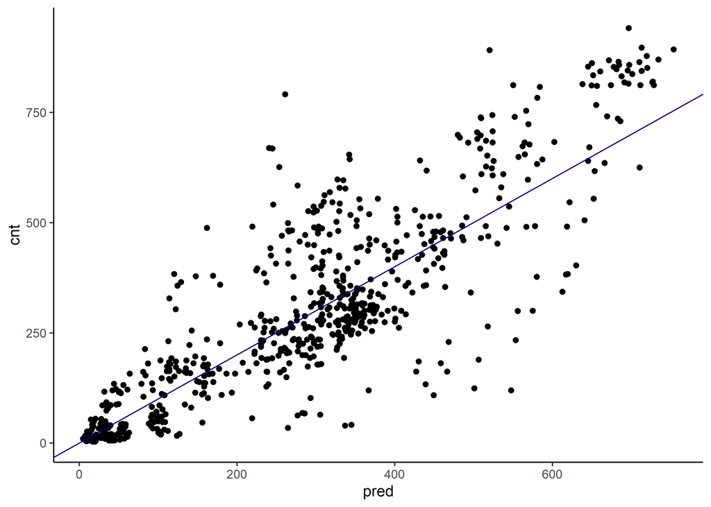

```r
# Plot predictions vs cnt (pred on x-axis)
ggplot(bikesAugust,
       aes(x = pred,
           y = cnt)) +
  geom_point() +
  geom_abline(color = "darkblue") +
  theme_classic()
```